# Week 5: git & GitHub

Version Control

Joe Nese

University of Oregon  
Fall 2025

# Homework Review

Homework 4

# git & GitHub

Week 5

## Agenda

- Introduce reasons for version control
- Introduce
  - git
  - GitHub
  - GitKraken

**Learning Objectives**

- Understand Introduce the basics of git and git terminology
- Be able to create repos, commit changes, push, pull, and clone
- Be prepared to collaborate on a project

## git & GitHub

**What are they?**

**git**

[figure not shown]

- a version control system
- lives on your computer and keeps track of files and all changes made to them that you register with commits

**GitHub**

[figure not shown]

- an online host for commits of code and data
- lives on the internet

## git & GitHub

Why are they important?

**Backup**: Easy way to upload files and add notes about changes. Excellent way to keep all your R work backed-up on the cloud

**Version Control**: Complete history of all changes and why they were made, and multiple branches of history

**Open Access**: Open, transparent, and public science. Some journals allow GitHub sites to be used to host data and code to meet their open-access requirements

**Visibility**: GitHub makes it easy to make your open-access work visible to people who might be interested (collaborators, employers)

**Collaborative tool**: Git and GitHub are designed for collaboration (even if you’re the only one coding). Easy to share files between collaborators, allows for merging work and reconciling conflicts.

**Job Skill**: This is an important data science skill

## git & GitHub

**How?**

1. Install git
2. Create a GitHub account (hopefully you all have done this)
3. Get a GUI and/or learn the command-line tools
   - I’m okay with either or both, as long as you (sort of) know what you’re doing
   - We’re going to use [GitKraken](https://www.gitkraken.com/) in this course
4. Develop a solid understanding of the underlying structure, so you know what you want to do even if you don’t know how
   - commits, push, pull, fork

## git can be frustrating, but…

It is transparent – mistakes and all

Can be a powerful tool for collaboration

- Communication between team members is important
- Try to avoid merge conflicts
  - One person working on one thing at a time
  - Pull first each and every time!
  - Push often/at logical points

Excellent for reproducibility (a tenet of the data science pipeline)

- Open data and code
- Transparent
- Forking paths

## Open & Reproducible Research

- Use scripting
- Use dynamic documents
  - Quarto is fantastic
- Use Git/GitHub
- Use open data whenever possible
  - Consider ways you can make portions of the data open, if not all of it
- Advanced – use tools that store software versions
  - `{renv}` (Rstudio)

## All the things

- **git** – a version control system that lives on your machine
- **GitHub** – repo host that lives online, works with git
- **GitKraken** – a GUI that lives on your machine and communicates with GitHub and git

## Version Control

We can think of the changes as separate from the document

You can then think about “playing back” different sets of changes on the base document, ultimately resulting in different versions of that document

[figure not shown]

[swcarpentry](https://swcarpentry.github.io/git-novice/01-basics/index.html)

## Version Control

This means there are many possible versions of the same document

[figure not shown]

[swcarpentry](https://swcarpentry.github.io/git-novice/01-basics/index.html)

## Version Control

Unless there are merge conflicts , two changes from the same document can be merged together

[figure not shown]

[swcarpentry](https://swcarpentry.github.io/git-novice/01-basics/index.html)

## Let’s talk about “how”

- Understand the structure of git
- Actual method of completing the tasks is up to you
  - GUI? Command line? RStudio?
- I’ve asked you to install [GitKraken](https://www.gitkraken.com/)
  - Worth it to manage merge conflicts alone
- If you’re already using something else, that’s ok!
  - Let me know

## Terminology

- **version control system**
  - A tool to help us track changes. git is one such system (but there are others)
- repository (repo)
  - The files, full commit history, and associated metadata for a project
- remote
  - The cloud-based server hosting the repo (that’s GitHub)

[figure not shown]

# Let’s connect GitHub and GitKraken

## Connect GitHub & GitKraken

**Go to GitKraken**

1. “Sign in with GitHub”
2. “Continue with Authorization”
3. You should see *“Success: GitHub and GitKraken are good to go!”* or something like that
4. Check your email for an email from GitHub to verify (?)

## Open GitKraken

[figure not shown]

## Connect GitHub and GitKraken

[figure not shown]

## Connect GitHub and GitKraken

Check your email (associated with your GitHub account)

[figure not shown]

# Creating a Repository

Starting with an empty project

*Follow along for your Homework!*

## Proposed Workflow

1. Go to GitHub
2. Create new repo
3. Copy path
4. Create a new RStudio Project
5. Go to GitKraken to manage

## 1. Go to GitHub

Select drop down by your profile, then “New Repository”

[figure not shown]

## 2. Create new repo

[figure not shown]

## 2. Create new repo

1. Give it a *Repository name*
2. Make it *Public* (this time)
3. *Add a README file*
4. *Add .gitignore*
   - `.gitignore template: R`
5. *Create repository*

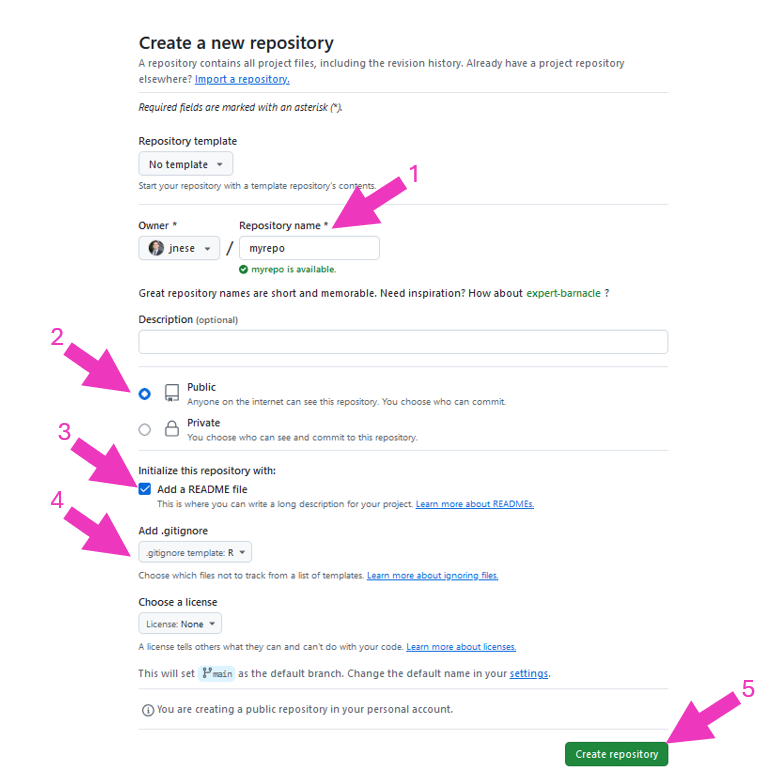

*License* - optional; I usually go with MIT

## Repo created!

[figure not shown]

## 3. Copy path

[figure not shown]

## 4. Create New RStudio Project

Select *Version Control*

[figure not shown]

## 4. Create New RStudio Project

Select *Git*

[figure not shown]

## 4. Create New RStudio Project

Clone Git Repository

[figure not shown]

## Clone Git Repository

- Paste GitHub URL into *Repository URL*
- Decide where your RProject will live on your machine
- *Create Project*

[figure not shown]

## This will open your new Rproj

- See files we created are there
- Where does it live?

[figure not shown]

## Let’s go to GitHub

Where is our `Rproj`

[figure not shown]

. . .

We haven’t pushed it yet

## 5. Go to GitKraken to manage

*File* *New Tab*

[figure not shown]

## 5. Go to GitKraken to manage

- In New Tab
- Select *Browse for a Repo*
- Open folder on your machine where your RProj lives

[figure not shown]

## Welcome to GitKraken

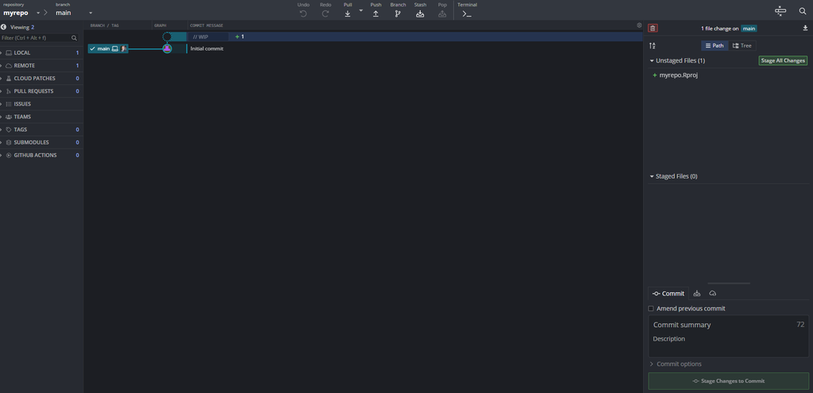

# Push Changes

## Welcome to GitKraken

We can see in two places that we have changes to our repo

1. “//WIP” - **W**ork **I**n **P**rogress
2. On the right under “*Unstaged Files*”

[figure not shown]

## Terminology

- stage
  - A file that is being prepared for a commit
- commit
  - Changes that have been made to the file(s)
- push
  - After you commit the changes you want, push them from the local to the remote

Half the battle is learning these terms

## Stage

“*Stage All Changes*” or

“*Stage File*” individually

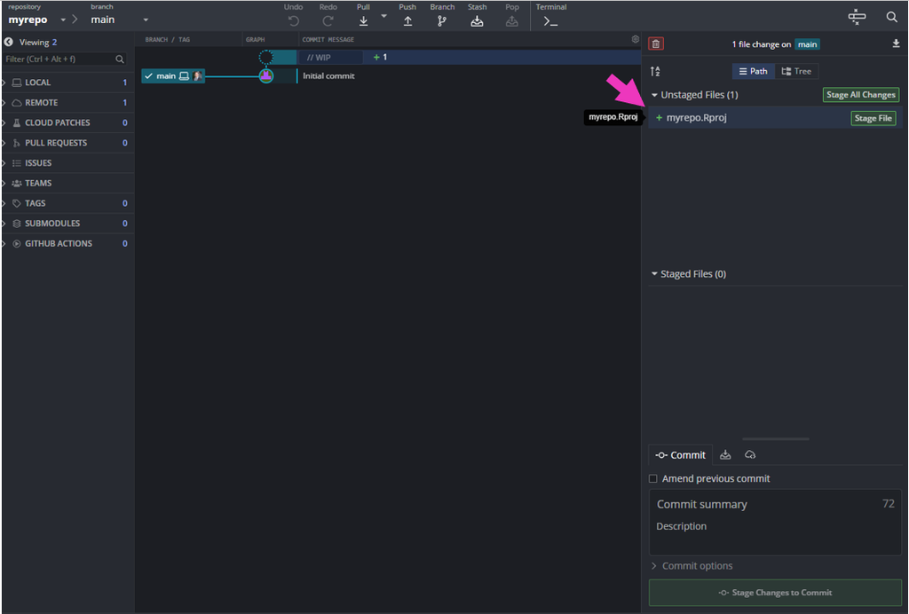

## Stage

Add a commit comment as a note you and your collaborators what the change was

[figure not shown]

## Commit

Commit changes

[figure not shown]

## Commit

- No *//WIP*
- Let’s check GitHub

No change

## Push

We need to push the change to GitHub

[figure not shown]

## GitHub

Now we see our changes

[figure not shown]

## Let’s make another change

- Make demo.qmd
- Render
- stage / commit / push
- Check GitHub
- Make edit
- Check GitKraken for change

demo

## Homework 5

- Submit a link to the repo you created today!
- Upload the link to Canvas
- See me if you were unable to complete in class (for technical reasons etc.)

It is ok if you leave today a little lot confused!

# Tracking

## Tracking

- As long as the `.git` folder exists, the entire folder will be tracked
- **Do not** create repos inside of repos
- If you want a folder to show up, there needs to be something in it (e.g., a README.md)

## Tracking

Show hidden files

PC

- Open *File Explorer*
- Select *View* at the top
- *Show* *Hidden Items*

Mac

- `cmd + shift + .`

## Ignoring files

- When we created the .Rproj the repo, we started it with a `.gitignore` file
- The `.gitignore` file tells the repo not to track certain files
  - e.g., proprietary data
- Not that important for now, but if you need to ignore a file in your repo for whatever reason, just put the name of the file(s) at the top of the `.gitignore` file
- Or, create a folder in your .Rproj (e..g, `nopublish`) and put all your documents to be ignored in that file
  - then on the first line of your `.gitignore` file, type: **nopublish/**

# Pull Changes

[figure not shown]

Image from Bryan (2017)

## Pull

- pull before you start any collaborative work!!
- pull any accepted changes from the remote to your local
- **pull before you start any collaborative work!!**

[figure not shown]

# Collaborating

## Collaborating

Two methods

1. Add users to a repo
2. Create an organization

## Collaborating

1. Add users to a repo
   - In your GitHub repo
   - *Settings* *Collaborators* *Manage Access* *Add people*
   - add user with their GitHub username

## Collaborating

2. Create an organization
   - *New organization*

[figure not shown]

## Collaborating

2. Create an organization
   - *New organization*

[figure not shown]